# GW_Yerik_Analysis

Yilin Zhu

29/09/2016

```r
gjb <- read.csv('/Users/Yerik/OneDrive/UK/Imperial College/BA/Modules/MSF/MSF_GW_Group_5/Dataset/June 10-July 12, 2015 - Gaming, Jobs and Broadband - CSV.csv', stringsAsFactors = FALSE)
#View(gjb)
#summary(gjb)
```

### Demographic Data

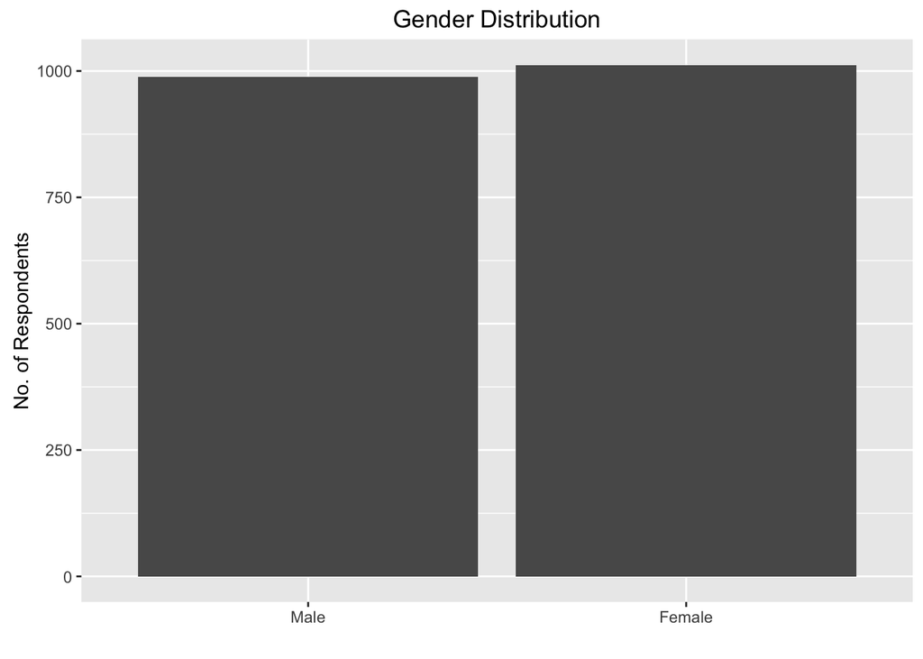

```r
ggplot(data = gjb, aes(x=factor(sex, levels=c(1,2), labels = c("Male","Female"))))+geom_bar(stat="count")+labs(x="",y="No. of Respondents",title="Gender Distribution")
```

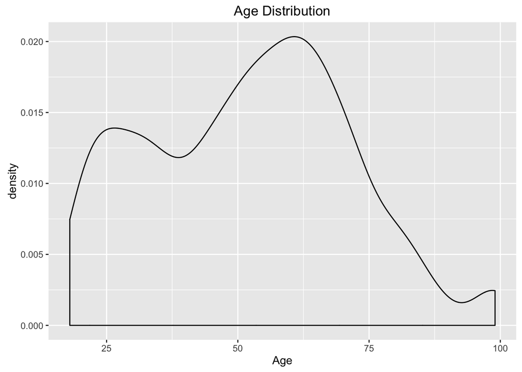

```r
ggplot(data = gjb, aes(x=age))+geom_density()+labs(x="Age",title="Age Distribution")
```

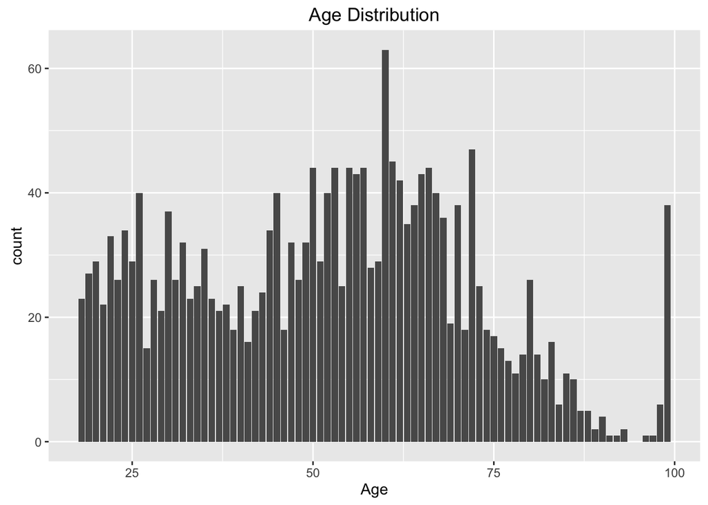

```r
ggplot(data = gjb, aes(x=age))+geom_bar(stat="count")+labs(x="Age",title="Age Distribution")
```

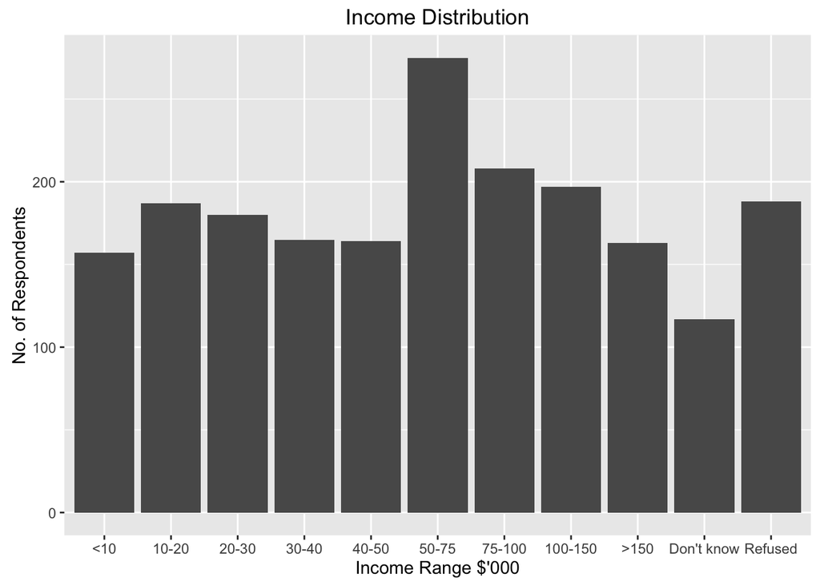

```r
ggplot(data = gjb, aes(x=factor(inc, levels=c(1:9,98,99), labels = c("<10","10-20","20-30","30-40","40-50","50-75","75-100","100-150",">150","Don't know","Refused"))))+geom_bar(stat="count")+labs(x="Income Range $'000",y="No. of Respondents",title="Income Distribution")
```

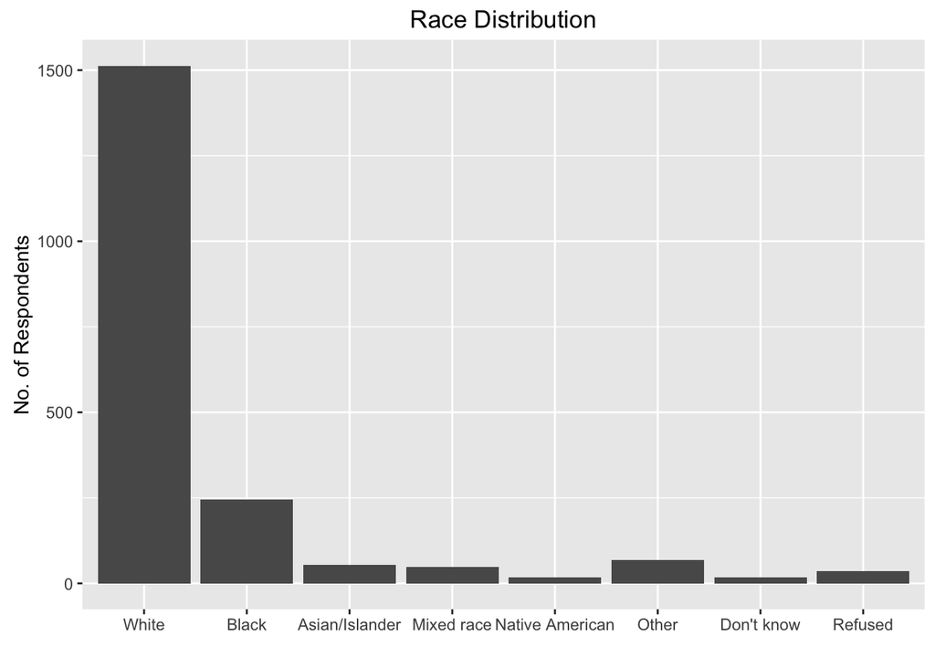

```r
ggplot(data = gjb, aes(x=factor(race, levels=c(1,2,3,4,5,6,8,9), labels = c("White","Black","Asian/Islander","Mixed race","Native American","Other","Don't know","Refused"))))+geom_bar(stat="count")+labs(x="",y="No. of Respondents",title="Race Distribution")
```

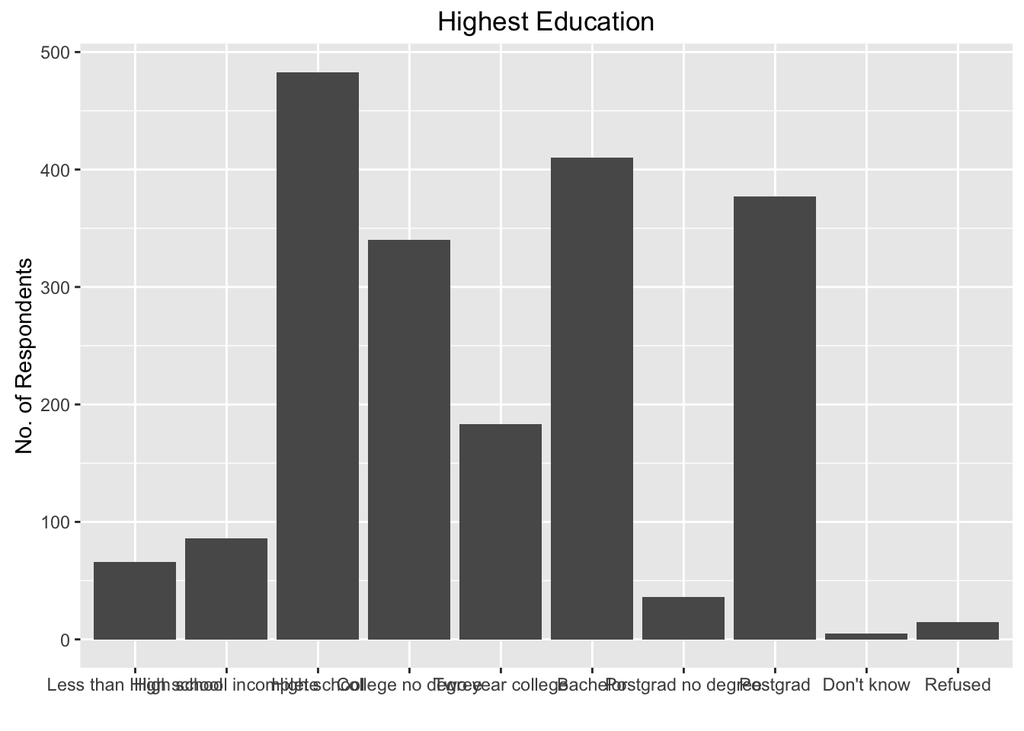

```r
ggplot(data = gjb, aes(x=factor(educ2, levels=c(1,2,3,4,5,6,7,8,98,99), labels = c("Less than High school","High school incomplete","High school","College no degree","Two year college","Bachelor","Postgrad no degree","Postgrad","Don't know","Refused"))))+geom_bar(stat="count")+labs(x="",y="No. of Respondents",title="Highest Education")
```

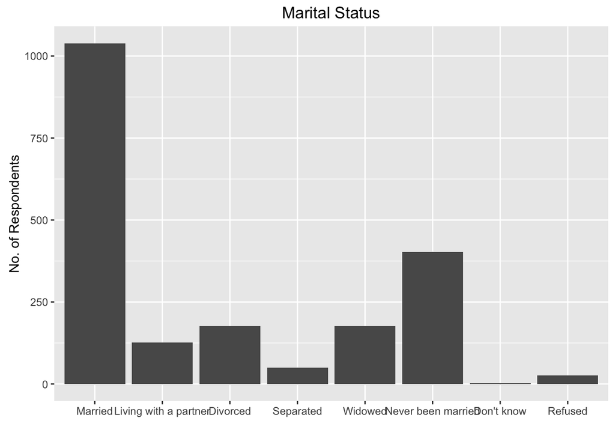

```r
ggplot(data = gjb, aes(x=factor(marital, levels=c(1,2,3,4,5,6,8,9), labels = c("Married","Living with a partner","Divorced","Separated","Widowed","Never been married","Don't know","Refused"))))+geom_bar(stat="count")+labs(x="",y="No. of Respondents",title="Marital Status")
```

### Q1: What’s the gender and age difference in online dating?

date1a: Have YOU, personally, ever used an online dating site such as Match.com, eHarmony, or OK Cupid?

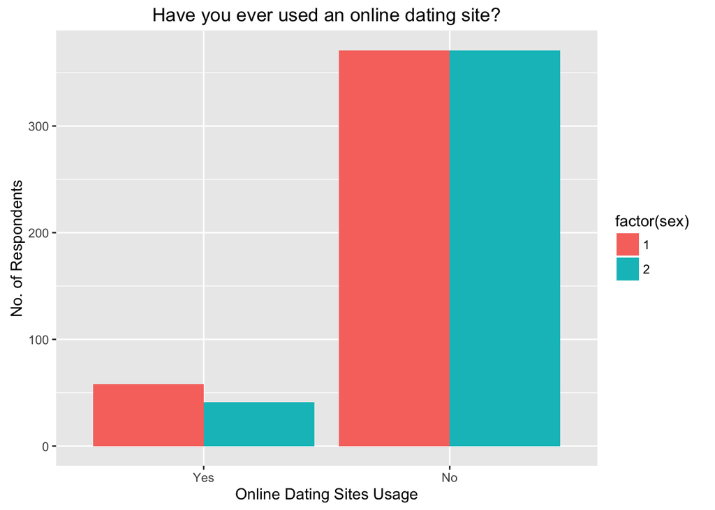

```r
date1a <- gjb[gjb[c("eminuse")]==1 | gjb[c("intmob")] ==1,] #extract the dataset for date1a
date1a <- date1a[date1a["date1a"] == c(1,2),] #remove the data of don't know and refused
ggplot(data = date1a)+geom_bar(aes(x=factor(date1a,levels=c(1,2),labels=c("Yes","No")),fill=factor(sex)),position="dodge",stat="count")+labs(x="Online Dating Sites Usage", y="No. of Respondents", title="Have you ever used an online dating site?")
```

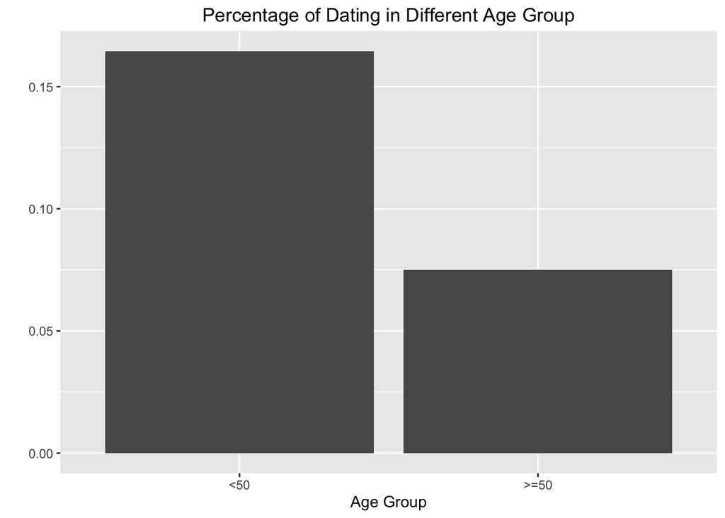

```r
date1a.age1 <- date1a[date1a["age"] < 50,]
p1 <- nrow(date1a.age1[date1a.age1["date1a"]==1,])/nrow(date1a.age1) #percent of dating in age<50
date1a.age2 <- date1a[date1a["age"] >= 50,]
p2 <- nrow(date1a.age2[date1a.age2["date1a"]==1,])/nrow(date1a.age2) #percent of dating in age>=50
date.age <- data.frame(age=c("<50",">=50"),percent=c(p1,p2))
ggplot(data = date.age)+geom_bar(aes(x=age,y=percent),stat="unique") +labs(x="Age Group", y="", title="Percentage of Dating in Different Age Group")
```

### Q2: Opinions about online dating

- “Online dating is a good way to meet people”
- “Online dating allows people to find a better match for themselves because they can get to know a lot more people”
- “People who use online dating sites are desperate”
- “Online dating keeps people from settling down because they always have options for people to date”
- “Online dating is easier and more efficient than other ways of meeting people”
- “Online dating is more dangerous than other ways of meeting people”)

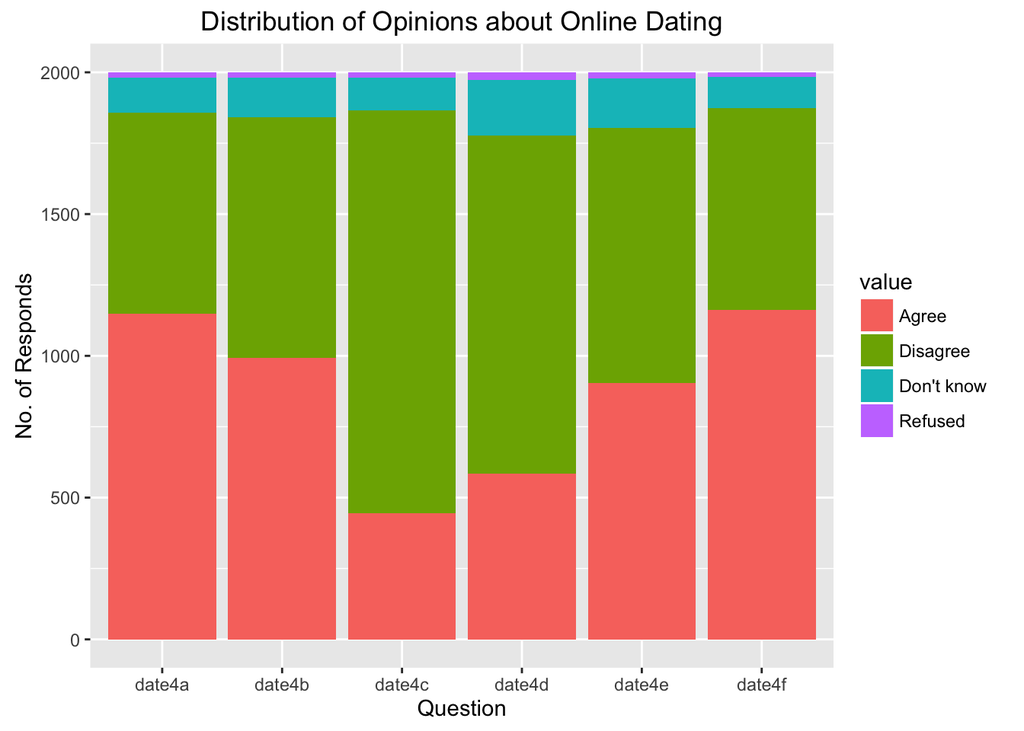

```r
date <- gjb[c("date4a","date4b","date4c","date4d","date4e","date4f")]
mdate <- melt(date, id.vars = 0)
mdate$value <- factor(mdate$value,levels=c(1,2,8,9),labels=c("Agree","Disagree","Don't know","Refused"))
ggplot(data = mdate, aes(x=variable,fill=value))+geom_bar(stat = "count")+labs(x="Question",y="No. of Responds",title="Distribution of Opinions about Online Dating")
```

Opinions in people who had no experience in online dating

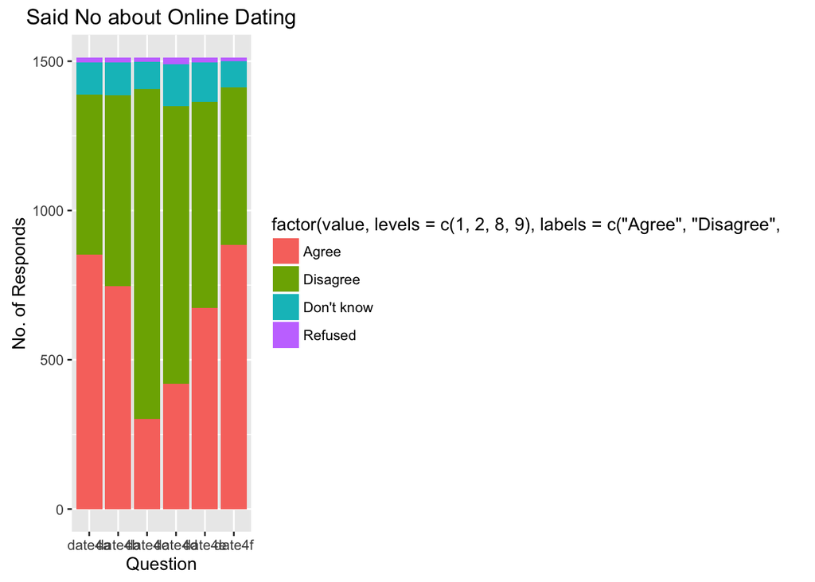

```r
date1a_no <- gjb[gjb["date1a"] == 2,c("date4a","date4b","date4c","date4d","date4e","date4f")]
date1a_no <- na.omit(date1a_no)
mdate4_no <- melt(date1a_no[,c("date4a","date4b","date4c","date4d","date4e","date4f")], id.vars = 0)
ggplot(data = mdate4_no, aes(x=variable,fill=factor(value,levels=c(1,2,8,9),labels=c("Agree","Disagree","Don't know","Refused"))))+geom_bar(stat = "count")+labs(x="Question",y="No. of Responds",title="Said No about Online Dating")
```

Opinions in people who had experience in online dating

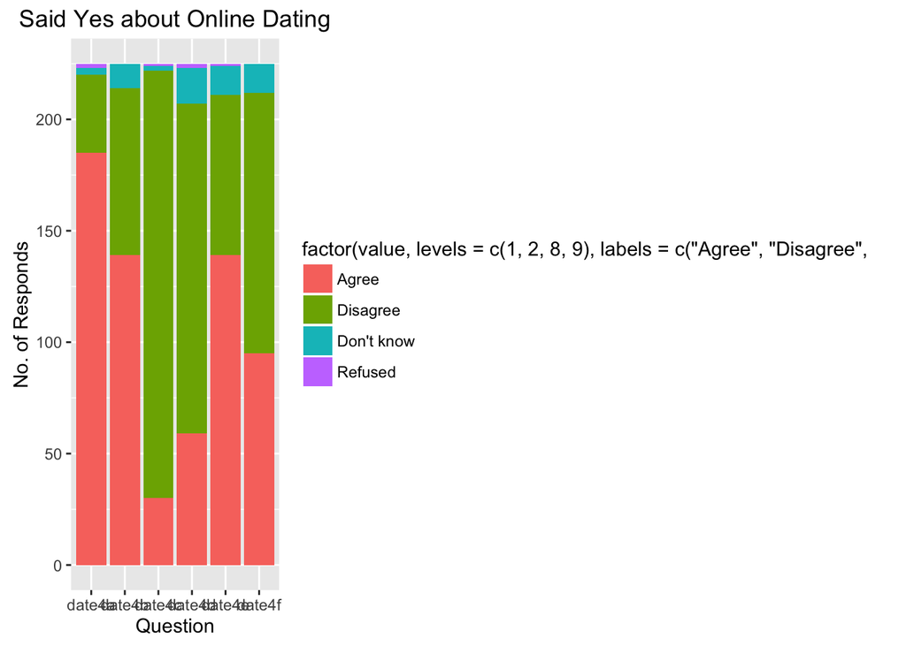

```r
date1a_yes <- gjb[gjb["date1a"] == 1,c("date4a","date4b","date4c","date4d","date4e","date4f")]
date1a_yes <- na.omit(date1a_yes)
mdate4_yes <- melt(date1a_yes[,c("date4a","date4b","date4c","date4d","date4e","date4f")], id.vars = 0)
ggplot(data = mdate4_yes, aes(x=variable,fill=factor(value,levels=c(1,2,8,9),labels=c("Agree","Disagree","Don't know","Refused"))))+geom_bar(stat = "count")+labs(x="Question",y="No. of Responds",title="Said Yes about Online Dating")
```

### Q3: What’s the gender and age difference in gaming?

game1: Do you ever play video games on a computer, TV, game console, or portable device like a cell phone?

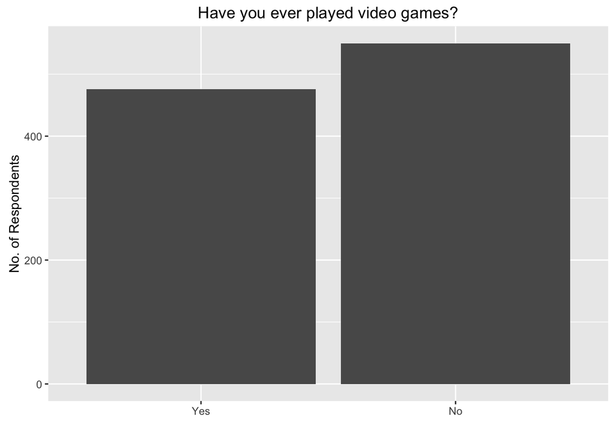

```r
game1 <- gjb[gjb["game1"] == c(1,2),]

#Overall
ggplot(data = game1)+geom_bar(aes(x=factor(game1,levels=c(1,2),labels=c("Yes","No"))),position="dodge",stat="count")+labs(x="", y="No. of Respondents", title="Have you ever played video games?")
```

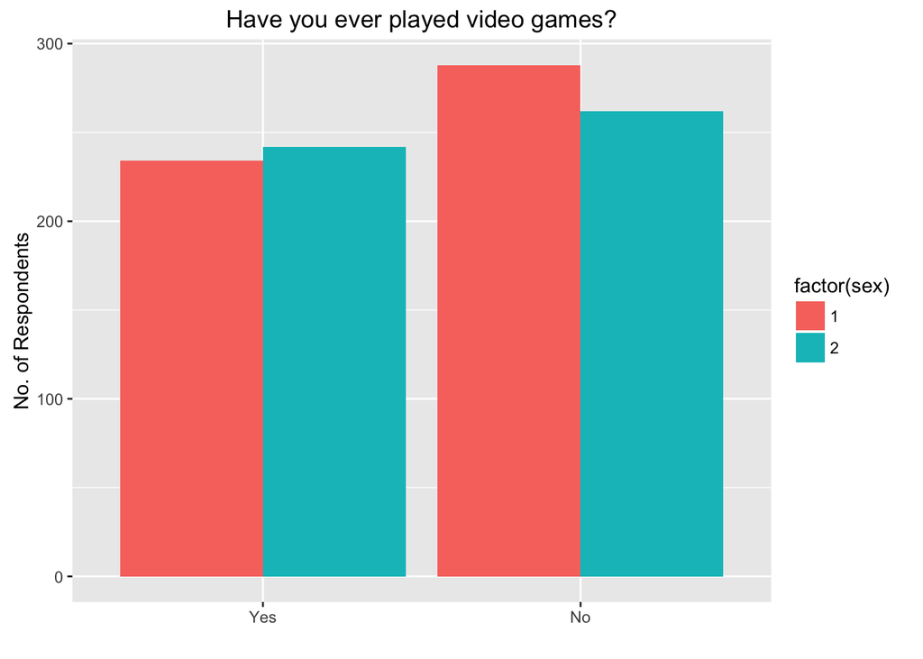

```r
#Gender
ggplot(data = game1)+geom_bar(aes(x=factor(game1,levels=c(1,2),labels=c("Yes","No")),fill=factor(sex)),position="dodge",stat="count")+labs(x="", y="No. of Respondents", title="Have you ever played video games?")
```

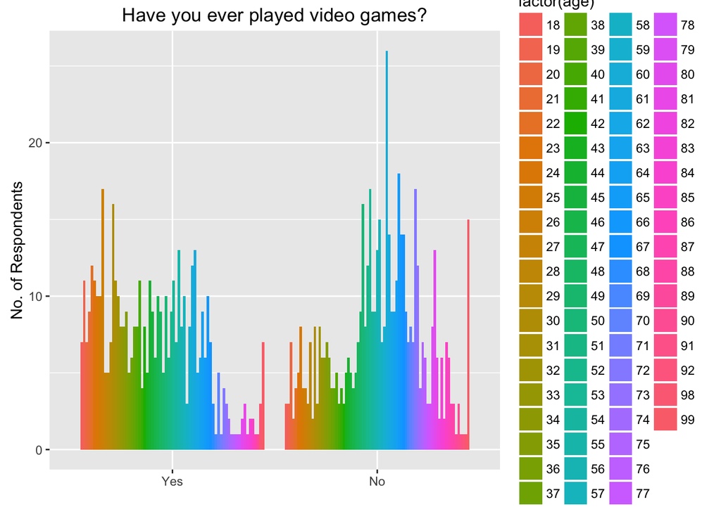

```r
#Age
ggplot(data = game1)+geom_bar(aes(x=factor(game1,levels=c(1,2),labels=c("Yes","No")),fill=factor(age)),position="dodge",stat="count")+labs(x="", y="No. of Respondents", title="Have you ever played video games?")
```